# Proyecto Final: Aislamiento por distancia en poblaciones del Chorlo Nevado (*Charadrius nivosus*)

De: Abner Herrera  
Para: Pavel García

D’Urban Jackson et al (2020) realizó un estudio en poblaciones del Chorlo Nevado (*C. nivosus*) para establecer las unidades de conservación de esta especie. En este estudio se puso a prueba la hipótesis de presencia de estructura genética en la especie utilizando diferentes marcadores genéticos: ADN mitocondrial (mtDNA), microsatelites, ligados al sexo (z) y autosómicos (single nucleotide polymorphisms - SNPs). Como parte del análisis también se evaluó si existe aislamiento reproductivo por distancia dada la amplia distribución de esta especie: desde el Norte de América, en Estados Unidos, hasta el Sur de América en Perú, y también en el Caribe (D’Urban Jackson et al, 2020).

En este proyecto se comprueba esta última hipótesis. *¿Existe aislamiento reproductivo por distancia en las poblaciones de C. nivosus?* Utiliando únicamente ADN mitocondrial, porque solo esos datos están disponibles desde la fuente del artículo (https://static-content.springer.com/esm/art%3A10.1007%2Fs10592-020-01256-8/MediaObjects/10592_2020_1256_MOESM1_ESM.docx), se encontró que si existe correlación entre la distancia genéticas y las distancia geográfica, con un valor de r = 0.502 (prueba de Mantel) y p < 0.05.

$$\begin{equation}
\tag{1}
Dc = \frac{2}{\pi r} \sum_{j=1}^r \sqrt{2\left(1 - \sum_{j=1}^{m_j}
\sqrt{x_{ij} y_{ij}}\right)}
\end{equation}$$

Como parte del procedimiento, el archivo FASTA utilizado aquí ya contiene las secuencias alineadas. Este paso se realizó en el software MEGA12.

Cuadro 1. Fragmento de la matriz de distancias genéticas.

```r
library("hierfstat") # Para calcular la matriz de distancias genéticas, Dch
library("adegenet") # Para importar las secuencias genéticas del archivo FASTA alineado
library("vegan") # Para hacer el test de mantel
library("geosphere") # Para calcular la matriz de distancias geográficas
library("MASS") # Para agregar la densidad de puntos en el gráfico de dispersión

# Se carga el archivo fasta con las 166 secuencias alineadas
seq = fasta2DNAbin('./mtDNA_aligned.fas')
```

[output not shown]

```r
obj = DNAbin2genind(seq) # Se almacena en un objeto genind propio del paquete adegenet.

# Se carga la información geográfica y el nombre de los sitios muestreados. Se asume que cada coordenada corresponde a una subpoblación.
meta <- read.table('./meta.csv', sep=',', header = T)

# Se agrega al objeto genind, pero no supe cómo trabajar las coordenadas dentro de este objeto para obtener las distancias geográficas.
obj$pop = as.factor(meta[match(rownames(obj$tab), meta$Genbank_accession),]$Site)

# Se convierte el objeto genind al objeto hierfstat para calcular el Fst.
obj.hf = genind2hierfstat(obj)

# Se calcula la matriz de distancias genéticas por el métdodo “Dch”: Cavalli-Sforza and Edwards Chord distance. This distance is used as default since Takezaki & Nei (1996) found that it was the best to retrieve the relation among samples.
# Como se trata de información genética mitocondrial, el atributo diploid se cambia a Falso, para trabajar con datos haploides.
# El método Dch se utiliza para más comúnmente para organismos haploides.
gen_dist <- genet.dist(obj.hf, method='Dch', diploid=F)
round(as.dist(as.matrix(gen_dist)[1:6, 1:6]), 7) # mostrar una pequeña parte de la matriz (es de 30x30)
```

```
                   Arequipa_Peru   Bermuda Big_Lagoon_Florida California_east Cayo_Costa_Florida
Bermuda                0.3580986
Big_Lagoon_Florida     0.3978874 0.1871978
California_east        0.3436393 0.2132781          0.0421210
Cayo_Costa_Florida     0.4095412 0.1975568          0.0095621       0.0516831
Colorado               0.3540800 0.2290479          0.0601244       0.0236328          0.0696866
```

En el cuadro 2 también se presenta una porción de la matriz de distancias geográficas entre los 30 sitios de muestreo. La distancia se expresa en km dadas las grandes distancias entre los puntos donde se han colectado las muestras.

Cuadro 2. Fragmento de la matriz de distancias geográficas

```r
# Calculo de la matriz de distancias geográficas.
# Se obtienen todos los sitios únicos (subpoblaciones) y se ordenan alfabéticamente, al igual que aparecen en la matriz de distancias genéticas.
sites <- unique(meta[, c("Site", "Lat", "Long")])
sites <- sites[order(sites$Site), ] # Este paso es CRÍTICO, dado que la correlación de Mantel revisa las posiciones de la matriz, asumiendo que tienen el mismo orden.

# Se obtiene la matriz de distancias en m.
geo_dist <- distm(sites[, c("Long", "Lat")], fun = distHaversine)
geo_dist <- geo_dist / 1000 # Se convierte a km.

# Cambia los nombres de filas y columnas de la matriz de distancias.
rownames(geo_dist) <- sites$Site
colnames(geo_dist) <- sites$Site

# Se convierte a una matriz que contiene los datos únicamente en la parte triangular de abajo, que es la que se usa en la prueba de Mantel.
geo_dist <- as.dist(geo_dist)
round(as.dist(as.matrix(geo_dist)[1:6, 1:6]), 7) # mostrar una pequeña parte de la matriz (es de 30x30)
```

```
                   Arequipa_Peru   Bermuda Big_Lagoon_Florida California_east Cayo_Costa_Florida
Bermuda                5550.6726
Big_Lagoon_Florida     5525.7575 2160.1742
California_east        7634.4340 4772.5184          2840.4967
Cayo_Costa_Florida     4999.2817 1804.8226           640.0838       3462.7356
Colorado               6957.1443 3487.1678          1668.3818       1287.1341          2308.4416
```

```r
# Test de Mantel
mantel_test <- mantel(gen_dist, geo_dist, method = "pearson", permutations = 9999)
#mantel_test

# Histograma de los resultados de Mantel
# Extrae las permunaciones para graficar la distribución
null_distribution <- mantel_test$perm
#null_distribution

# Gráfico con el valor calculado, las permutaciones y el IC de 95%
hist(null_distribution,
     breaks = 30,
     col = "#afc4b4",
     main = "Distribución nula del test de Mantel",
     xlab = "Estadístico de Mantel (r)",
     ylab = "Frequencia",
     xlim = range(c(null_distribution, mantel_test$statistic)))

abline(v = mantel_test$statistic, col = "#9c2c33", lwd = 2) # r calculado
```

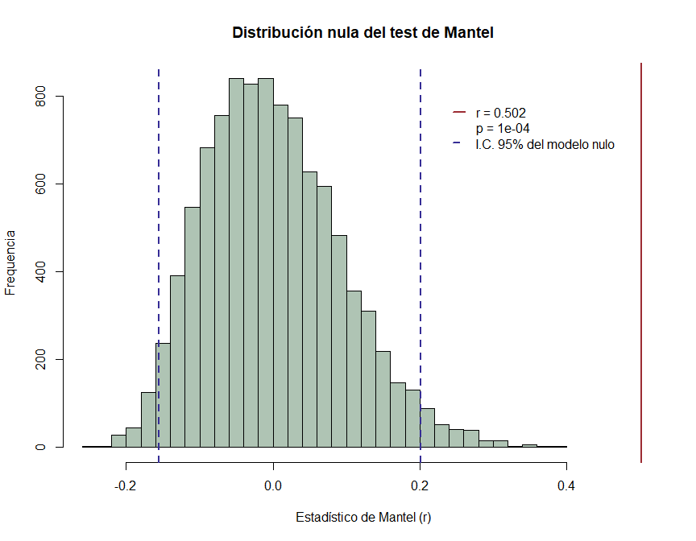

```r
quantiles <- quantile(null_distribution, probs = c(0.025, 0.975)) # IC 95%
abline(v = quantiles, col = "#362d96", lwd = 2, lty = 2)

legend(x = 0.23, y = 800,
       legend = c(paste0("r = ", round(mantel_test$statistic, 3)), paste0("p = ", mantel_test$signif), "I.C. 95% del modelo nulo"),
       col = c("#9c2c33", NA, "#362d96"),
       lwd = c(2, NA, 2),
       lty = c(1, NA, 2),
       seg.len = 1,
       bty = "n")
```

Figura 1. Histograma de la distribución nula del test de Mantel y el valor r calculado.

El test de Mantel se realizó con 9999 permutaciones, replicando el número de permutaciones del artículo original.

```r
# Gráfico de dispersión de la distancia geográfica y distancia genética

# Calcula la densidad de puntos dentro del gráfico, permite saber donde está concentrado la mayoría de nuestros datos.
dens <- kde2d(as.vector(geo_dist), as.vector(gen_dist), n=300)

# Asigna diferentes colores para distinguir las densidades, de blanco a rojo que equivale de menor a mayor densidad.
myPal <- colorRampPalette(c("white", "blue", "gold", "orange", "red"))
plot(geo_dist, gen_dist, pch=20,cex=.5,
     xlab = "Distancia geográfica (km)",
     ylab = "Distancia genética (Dch)")
image(dens, col=transp(myPal(300),.7), add=TRUE)
```

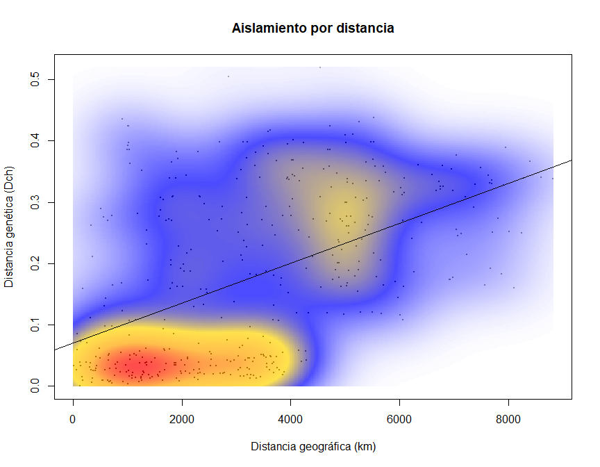

```r
title("Aislamiento por distancia")

# Regresión lineal entre las distancias geográficas y genéticas.
modelo <- lm(as.vector(gen_dist) ~ as.vector(geo_dist))
abline(modelo)
```

Figura 2. Gráfico de dispersión entre la distancia geográfica y genética de las poblaciones observadas.

## Referencias:

D’Urban Jackson, J., Bruford, M.W., Székely, T. et al. Population differentiation and historical demography of the threatened snowy plover *Charadrius nivosus* (Cassin, 1858). *Conserv Genet 21*, 387–404 (2020). https://doi.org/10.1007/s10592-020-01256-8

Goudet, J., Jombart, T., Kamvar, Z. N., Archer, E. & Hardy, O. (2022). *Estimation and Tests of Hierarchical F-Statistics: Package ‘hierfstat’*. https://cran.r-project.org/web/packages/hierfstat/hierfstat.pdf.

Takezaki, N. & Nei, M. (1996). *Genetic distances and reconstruction of Phylogenetic trees from microsatellite DNA*. Genetics 144:389-399